# Preparación docente · limpieza de GBIF y generación de paquetes municipales

2026-09-09

> Este cuaderno prepara los datos que recibirán los estudiantes. **No forma parte del trabajo estudiantil.** Está diseñado para ejecutarse con el CSV grande de GBIF `datos_fuente/0003509-260715120105164.csv`, que no se incluye en el repositorio.

# 1. Paquetes y parámetros

```r
knitr::opts_chunk$set(message = FALSE, warning = FALSE)

library(data.table)
library(dplyr)
library(tidyr)
library(stringr)
library(purrr)
library(sf)
```

```r
library(CoordinateCleaner)
library(readr)
library(tibble)
library(ggplot2)

raiz <- if (file.exists("biogeografia-pa02.Rproj")) "." else ".."
source(file.path(raiz, "R", "funciones_pa02.R"))

ruta_gbif <- file.path(raiz, "datos_fuente", "0003509-260715120105164.csv")
ruta_municipios <- file.path(raiz, "datos_fuente", "municipios-rd.gpkg")
ruta_h3 <- file.path(raiz, "datos_fuente", "all_sources_all_variables_res_7.gpkg")
dir_salida <- file.path(raiz, "datos_por_municipio")
dir.create(dir_salida, showWarnings = FALSE, recursive = TRUE)

# Criterios conservadores, fáciles de cambiar antes de regenerar los paquetes
buffer_centroide_m <- 2000
buffer_institucion_m <- 2000
incertidumbre_max_m <- 5000

# Umbrales OPERATIVOS para recomendar municipios
min_registros_apto <- 200
min_especies_apto <- 200
min_hex_5spp_apto <- 15

min_hex_5spp_condicional <- 8
min_especies_condicional <- 120
```

# 2. Leer y revisar capas espaciales

```r
municipios <- st_read(ruta_municipios, quiet = TRUE) |>
  mutate(
    provincia_codigo = PROV,
    municipio_codigo = MUN,
    municipio = TOPONIMIA,
    id_municipio = ENLACE
  )

h3 <- st_read(ruta_h3, quiet = TRUE, optional = TRUE)

st_crs(municipios)
```

```
## Coordinate Reference System:
##   User input: WGS 84 / UTM zone 19N
##   wkt:
## PROJCRS["WGS 84 / UTM zone 19N",
##     BASEGEOGCRS["WGS 84",
##         ENSEMBLE["World Geodetic System 1984 ensemble",
##             MEMBER["World Geodetic System 1984 (Transit)"],
##             MEMBER["World Geodetic System 1984 (G730)"],
##             MEMBER["World Geodetic System 1984 (G873)"],
##             MEMBER["World Geodetic System 1984 (G1150)"],
##             MEMBER["World Geodetic System 1984 (G1674)"],
##             MEMBER["World Geodetic System 1984 (G1762)"],
##             MEMBER["World Geodetic System 1984 (G2139)"],
##             ELLIPSOID["WGS 84",6378137,298.257223563,
##                 LENGTHUNIT["metre",1]],
##             ENSEMBLEACCURACY[2.0]],
##         PRIMEM["Greenwich",0,
##             ANGLEUNIT["degree",0.0174532925199433]],
##         ID["EPSG",4326]],
##     CONVERSION["UTM zone 19N",
##         METHOD["Transverse Mercator",
##             ID["EPSG",9807]],
##         PARAMETER["Latitude of natural origin",0,
##             ANGLEUNIT["degree",0.0174532925199433],
##             ID["EPSG",8801]],
##         PARAMETER["Longitude of natural origin",-69,
##             ANGLEUNIT["degree",0.0174532925199433],
##             ID["EPSG",8802]],
##         PARAMETER["Scale factor at natural origin",0.9996,
##             SCALEUNIT["unity",1],
##             ID["EPSG",8805]],
##         PARAMETER["False easting",500000,
##             LENGTHUNIT["metre",1],
##             ID["EPSG",8806]],
##         PARAMETER["False northing",0,
##             LENGTHUNIT["metre",1],
##             ID["EPSG",8807]]],
##     CS[Cartesian,2],
##         AXIS["(E)",east,
##             ORDER[1],
##             LENGTHUNIT["metre",1]],
##         AXIS["(N)",north,
##             ORDER[2],
##             LENGTHUNIT["metre",1]],
##     USAGE[
##         SCOPE["Engineering survey, topographic mapping."],
##         AREA["Between 72°W and 66°W, northern hemisphere between equator and 84°N, onshore and offshore. Aruba. Bahamas. Brazil. Canada - New Brunswick (NB); Labrador; Nunavut; Nova Scotia (NS); Quebec. Colombia. Dominican Republic. Greenland. Netherlands Antilles. Puerto Rico. Turks and Caicos I…
##         BBOX[0,-72,84,-66]],
##     ID["EPSG",32619]]
```

```r
st_crs(h3)
```

```
## Coordinate Reference System:
##   User input: WGS 84
##   wkt:
## GEOGCRS["WGS 84",
##     ENSEMBLE["World Geodetic System 1984 ensemble",
##         MEMBER["World Geodetic System 1984 (Transit)"],
##         MEMBER["World Geodetic System 1984 (G730)"],
##         MEMBER["World Geodetic System 1984 (G873)"],
##         MEMBER["World Geodetic System 1984 (G1150)"],
##         MEMBER["World Geodetic System 1984 (G1674)"],
##         MEMBER["World Geodetic System 1984 (G1762)"],
##         MEMBER["World Geodetic System 1984 (G2139)"],
##         ELLIPSOID["WGS 84",6378137,298.257223563,
##             LENGTHUNIT["metre",1]],
##         ENSEMBLEACCURACY[2.0]],
##     PRIMEM["Greenwich",0,
##         ANGLEUNIT["degree",0.0174532925199433]],
##     CS[ellipsoidal,2],
##         AXIS["geodetic latitude (Lat)",north,
##             ORDER[1],
##             ANGLEUNIT["degree",0.0174532925199433]],
##         AXIS["geodetic longitude (Lon)",east,
##             ORDER[2],
##             ANGLEUNIT["degree",0.0174532925199433]],
##     USAGE[
##         SCOPE["Horizontal component of 3D system."],
##         AREA["World."],
##         BBOX[-90,-180,90,180]],
##     ID["EPSG",4326]]
```

```r
nrow(municipios)
```

```
## [1] 155
```

```r
nrow(h3)
```

```
## [1] 13201
```

```r
ncol(h3)
```

```
## [1] 143
```

Las capas de entrada usan CRS distintos. Para operaciones de punto-en-polígono transformaremos los municipios a EPSG:4326. Para áreas/distancias, si fueran necesarias, se utilizará EPSG:32619.

```r
municipios_ll <- st_transform(municipios, 4326)
stopifnot(st_crs(h3)$epsg == 4326)
```

# 3. Leer el CSV grande de GBIF

`data.table::fread()` detecta automáticamente el separador y es apropiado para un archivo de cientos de miles de filas.

```r
stopifnot(file.exists(ruta_gbif))
gbif <- fread(ruta_gbif, data.table = FALSE, showProgress = TRUE)

nrow(gbif)
```

```
## [1] 193119
```

```r
ncol(gbif)
```

```
## [1] 50
```

```r
names(gbif)
```

```
##  [1] "gbifID"                           "datasetKey"
##  [3] "occurrenceID"                     "kingdom"
##  [5] "phylum"                           "class"
##  [7] "order"                            "family"
##  [9] "genus"                            "species"
## [11] "infraspecificEpithet"             "taxonRank"
## [13] "scientificName"                   "verbatimScientificName"
## [15] "verbatimScientificNameAuthorship" "countryCode"
## [17] "locality"                         "stateProvince"
## [19] "occurrenceStatus"                 "individualCount"
## [21] "publishingOrgKey"                 "decimalLatitude"
## [23] "decimalLongitude"                 "coordinateUncertaintyInMeters"
## [25] "coordinatePrecision"              "elevation"
## [27] "elevationAccuracy"                "depth"
## [29] "depthAccuracy"                    "eventDate"
## [31] "day"                              "month"
## [33] "year"                             "taxonKey"
## [35] "speciesKey"                       "basisOfRecord"
## [37] "institutionCode"                  "collectionCode"
## [39] "catalogNumber"                    "recordNumber"
## [41] "identifiedBy"                     "dateIdentified"
## [43] "license"                          "rightsHolder"
## [45] "recordedBy"                       "typeStatus"
## [47] "establishmentMeans"               "lastInterpreted"
## [49] "mediaType"                        "issue"
```

# 4. Normalización taxonómica mínima

La matriz de comunidad será a nivel de **especie**. Si existe la columna `species`, se usa para colapsar registros infraespecíficos a su especie; de lo contrario se intenta `acceptedScientificName` y después `scientificName`.

```r
gbif$especie <- nombre_especie_preferido(gbif)

if ("occurrenceStatus" %in% names(gbif)) {
  gbif <- gbif |> filter(is.na(occurrenceStatus) | toupper(occurrenceStatus) != "ABSENT")
}
if ("basisOfRecord" %in% names(gbif)) {
  gbif <- gbif |> filter(is.na(basisOfRecord) | toupper(basisOfRecord) != "FOSSIL_SPECIMEN")
}

gbif <- gbif |>
  filter(!is.na(especie), especie != "")
```

# 5. Validación básica de coordenadas

`cc_val()` debe aplicarse antes de las demás pruebas de `CoordinateCleaner`.

```r
stopifnot(all(c("decimalLongitude", "decimalLatitude") %in% names(gbif)))

gbif$decimalLongitude <- suppressWarnings(as.numeric(gbif$decimalLongitude))
gbif$decimalLatitude <- suppressWarnings(as.numeric(gbif$decimalLatitude))

flag_val <- CoordinateCleaner::cc_val(
  gbif,
  lon = "decimalLongitude", lat = "decimalLatitude",
  value = "flagged", verbose = TRUE
)

gbif_validas <- gbif[flag_val, , drop = FALSE]
```

# 6. Banderas de CoordinateCleaner

En lugar de encadenar eliminaciones sin saber por qué desapareció cada fila, se crea una bandera por prueba. `TRUE` significa que el registro **superó** la prueba.

```r
gbif_validas$cc_zero_ok <- CoordinateCleaner::cc_zero(
  gbif_validas, lon = "decimalLongitude", lat = "decimalLatitude",
  value = "flagged", verbose = TRUE
)

gbif_validas$cc_centroid_ok <- CoordinateCleaner::cc_cen(
  gbif_validas, lon = "decimalLongitude", lat = "decimalLatitude",
  species = "especie", buffer = buffer_centroide_m,
  geod = TRUE, test = "both", value = "flagged", verbose = TRUE
)

gbif_validas$cc_inst_ok <- CoordinateCleaner::cc_inst(
  gbif_validas, lon = "decimalLongitude", lat = "decimalLatitude",
  species = "especie", buffer = buffer_institucion_m,
  geod = TRUE, value = "flagged", verbose = TRUE
)
```

> **Nota metodológica.** La prueba de instituciones es deliberadamente conservadora y puede eliminar ocurrencias biológicamente reales cerca de jardines botánicos, universidades o herbarios. Por eso se exporta también un registro de rechazos y se conserva el motivo. El buffer puede modificarse tras revisar el mapa.

# 7. Incertidumbre de coordenadas

Debido a que H3 res. 7 tiene celdas de pocos kilómetros, se marca como problemática una incertidumbre conocida superior al umbral elegido. Los `NA` no se eliminan automáticamente: representan incertidumbre **no documentada**, que deberá discutirse.

```r
if ("coordinateUncertaintyInMeters" %in% names(gbif_validas)) {
  gbif_validas <- gbif_validas |>
    mutate(
      coordinateUncertaintyInMeters = suppressWarnings(as.numeric(coordinateUncertaintyInMeters)),
      incertidumbre_ok = is.na(coordinateUncertaintyInMeters) |
        coordinateUncertaintyInMeters <= incertidumbre_max_m
    )
} else {
  gbif_validas$incertidumbre_ok <- TRUE
}
```

# 8. Filtrado espacial con la capa oficial de municipios

Esta operación tiene dos propósitos: eliminar puntos fuera del territorio municipal usado en la práctica —incluidos puntos en el mar— y asignar cada registro a **un municipio concreto**.

```r
pts <- st_as_sf(
  gbif_validas,
  coords = c("decimalLongitude", "decimalLatitude"),
  crs = 4326,
  remove = FALSE
)

pts_mun <- st_join(
  pts,
  municipios_ll |>
    select(provincia_codigo, municipio_codigo, municipio, id_municipio),
  join = st_within,
  left = TRUE
)

pts_mun <- pts_mun |>
  mutate(
    municipio_ok = !is.na(id_municipio),
    limpieza_ok = cc_zero_ok &
      cc_centroid_ok &
      cc_inst_ok &
      incertidumbre_ok &
      municipio_ok
  )
```

# 9. Duplicados exactos y asignación a H3

No se elimina el hecho de que varias especies puedan compartir coordenadas. Se eliminan solamente duplicados exactos del identificador de ocurrencia cuando esté disponible. Después cada punto limpio se asigna a un `hex_id` mediante unión espacial.

```r
pts_ok <- pts_mun |> filter(limpieza_ok)

if ("occurrenceID" %in% names(pts_ok)) {
  pts_ok <- pts_ok |>
    arrange(occurrenceID) |>
    distinct(occurrenceID, .keep_all = TRUE)
}

pts_h3 <- st_join(
  pts_ok,
  h3 |> select(hex_id),
  join = st_within,
  left = TRUE
) |>
  filter(!is.na(hex_id))
```

# 10. Diagnóstico nacional de muestreo

Calculamos métricas útiles para decidir qué municipios pueden soportar los análisis de la práctica.

```r
tmp_hex <- pts_h3 |> st_drop_geometry()
if ("occurrenceID" %in% names(tmp_hex)) {
  tmp_hex <- tmp_hex |> distinct(id_municipio, hex_id, especie, occurrenceID, .keep_all = TRUE)
}

por_hex <- tmp_hex |>
  group_by(id_municipio, hex_id) |>
  summarise(
    n_registros = n(),
    riqueza = n_distinct(especie),
    .groups = "drop"
  )

spp_hex <- pts_h3 |>
  st_drop_geometry() |>
  distinct(id_municipio, hex_id, especie) |>
  count(id_municipio, especie, name = "n_hex")

h3_hab <- h3
h3_hab$habitat_esa <- clasificar_habitat_esa(h3_hab)
h3_hab <- h3_hab |>
  select(hex_id, habitat_esa)

hab_mun <- por_hex |>
  left_join(st_drop_geometry(h3_hab), by = "hex_id") |>
  count(id_municipio, habitat_esa, name = "n_hex")

resumen_mun <- pts_h3 |>
  st_drop_geometry() |>
  group_by(id_municipio, municipio, provincia_codigo) |>
  summarise(
    n_registros = n(),
    n_especies = n_distinct(especie),
    n_hex_con_registros = n_distinct(hex_id),
    .groups = "drop"
  ) |>
  left_join(
    por_hex |>
      group_by(id_municipio) |>
      summarise(
        n_hex_5spp = sum(riqueza >= 5),
        mediana_registros_hex = median(n_registros),
        .groups = "drop"
      ),
    by = "id_municipio"
  ) |>
  left_join(
    spp_hex |>
      group_by(id_municipio) |>
      summarise(n_especies_3hex = sum(n_hex >= 3), .groups = "drop"),
    by = "id_municipio"
  ) |>
  left_join(
    hab_mun |>
      filter(!is.na(habitat_esa), n_hex >= 3) |>
      count(id_municipio, name = "n_grupos_habitat_3hex"),
    by = "id_municipio"
  ) |>
  mutate(
    n_grupos_habitat_3hex = replace_na(n_grupos_habitat_3hex, 0L),

    categoria = case_when(

      n_registros >= min_registros_apto &
        n_especies >= min_especies_apto &
        n_hex_5spp >= min_hex_5spp_apto ~ "APTO",

      n_especies >= min_especies_condicional &
        n_hex_5spp >= min_hex_5spp_condicional ~ "CONDICIONAL",

      TRUE ~ "NO RECOMENDADO"
    )
  ) |>
  arrange(desc(categoria == "APTO"), desc(n_hex_5spp), desc(n_especies))

write_csv(resumen_mun, file.path(dir_salida, "00_resumen_elegibilidad_municipios.csv"))
resumen_mun
```

```
## # A tibble: 155 × 11
##    id_municipio municipio             provincia_codigo n_registros n_especies
##    <chr>        <chr>                 <chr>                  <int>      <int>
##  1 061601       PEDERNALES            16                      4124       1340
##  2 021302       CONSTANZA             13                      5583       1715
##  3 081101       HIGÜEY                11                      3316        774
##  4 021303       JARABACOA             13                      3451       1236
##  5 051701       BANÍ                  17                      1745        753
##  6 012505       SAN JOSÉ DE LAS MATAS 25                      1071        583
##  7 053101       SAN JOSÉ DE OCOA      31                      1963        843
##  8 061002       DUVERGÉ               10                      2163        861
##  9 032001       SAMANÁ                20                      1307        522
## 10 081102       SAN RAFAEL DEL YUMA   11                      1802        632
## # ℹ 145 more rows
## # ℹ 6 more variables: n_hex_con_registros <int>, n_hex_5spp <int>,
## #   mediana_registros_hex <dbl>, n_especies_3hex <int>,
## #   n_grupos_habitat_3hex <int>, categoria <chr>
```

Los umbrales anteriores son **operativos**: sirven para impedir que un estudiante reciba un municipio con una matriz demasiado pequeña. Deben revisarse después de mirar la distribución real.

# 11. Tabla de motivos de exclusión

```r
rechazos <- pts_mun |>
  st_drop_geometry() |>
  mutate(
    motivo = case_when(
      !cc_zero_ok ~ "coordenada_cero",
      !cc_centroid_ok ~ "centroide_administrativo",
      !cc_inst_ok ~ "proximidad_institucion",
      !incertidumbre_ok ~ "incertidumbre_excesiva",
      !municipio_ok ~ "fuera_municipios_rd_o_mar",
      TRUE ~ "aceptado"
    )
  )

write_csv(
  rechazos |> count(motivo, name = "n"),
  file.path(dir_salida, "00_resumen_limpieza.csv")
)
```

# 12. Generar un paquete por municipio

Cada directorio municipal contendrá registros GBIF, H3 ambientales completos y el límite municipal. Se exportan **datos básicos**, no las matrices ya filtradas: construirlas forma parte de la práctica estudiantil.

```r
slugify <- function(x) {
  x |>
    iconv(to = "ASCII//TRANSLIT") |>
    tolower() |>
    str_replace_all("[^a-z0-9]+", "-") |>
    str_replace_all("(^-|-$)", "")
}

campos_gbif_preferidos <- c(
  "occurrenceID", "gbifID", "especie", "scientificName", "acceptedScientificName",
  "family", "genus", "taxonRank", "basisOfRecord", "eventDate", "year",
  "decimalLongitude", "decimalLatitude", "coordinateUncertaintyInMeters",
  "datasetKey", "institutionCode", "collectionCode",
  "provincia_codigo", "municipio_codigo", "municipio", "id_municipio", "hex_id"
)

ids <- resumen_mun |> filter(categoria %in% c("APTO", "CONDICIONAL")) |> pull(id_municipio)

walk(ids, function(id) {
  info <- resumen_mun |> filter(id_municipio == id) |> slice(1)
  slug <- slugify(info$municipio)
  d <- file.path(dir_salida, paste0(id, "_", slug))
  dir.create(d, showWarnings = FALSE, recursive = TRUE)

  reg <- pts_h3 |> filter(id_municipio == id)
  campos <- intersect(campos_gbif_preferidos, names(reg))
  reg_csv <- reg |>
    st_drop_geometry() |>
    select(all_of(campos))
  write_csv(reg_csv, file.path(d, paste0("gbif_flora_", slug, ".csv")))

  mun <- municipios |> filter(id_municipio == id)
  mun_ll <- st_transform(mun, 4326)

  # Se incluyen TODOS los H3 que intersectan el municipio, incluso sin registros GBIF.
  # Esto permite visualizar espacialmente el sesgo de muestreo.
  toca <- lengths(st_intersects(h3, mun_ll)) > 0
  h3_m <- h3[toca, ]
  h3_m$habitat_esa <- clasificar_habitat_esa(h3_m)
  st_write(h3_m, file.path(d, paste0("h3_ambiental_", slug, ".gpkg")), delete_dsn = TRUE, quiet = TRUE)

  st_write(mun, file.path(d, paste0("municipio_", slug, ".gpkg")), delete_dsn = TRUE, quiet = TRUE)

  write_csv(info, file.path(d, "resumen_municipio.csv"))
})
```

> Cada paquete incluye **todos los H3 que intersectan el municipio**, incluso los que no contienen registros GBIF. Esto permite cartografiar áreas ambientales disponibles pero no muestreadas y hace visible el sesgo espacial de observación.

# 13. Exportar auditoría nacional

```r
dir.create(file.path(dir_salida, "_auditoria"), showWarnings = FALSE, recursive = TRUE)

st_write(
  pts_h3,
  file.path(dir_salida, "_auditoria", "gbif_flora_limpio_con_h3.gpkg"),
  delete_dsn = TRUE,
  quiet = TRUE
)

saveRDS(
  list(
    resumen_mun = resumen_mun,
    por_hex = por_hex,
    spp_hex = spp_hex
  ),
  file.path(dir_salida, "_auditoria", "diagnostico_muestreo.rds")
)
```

# 14. Control visual nacional

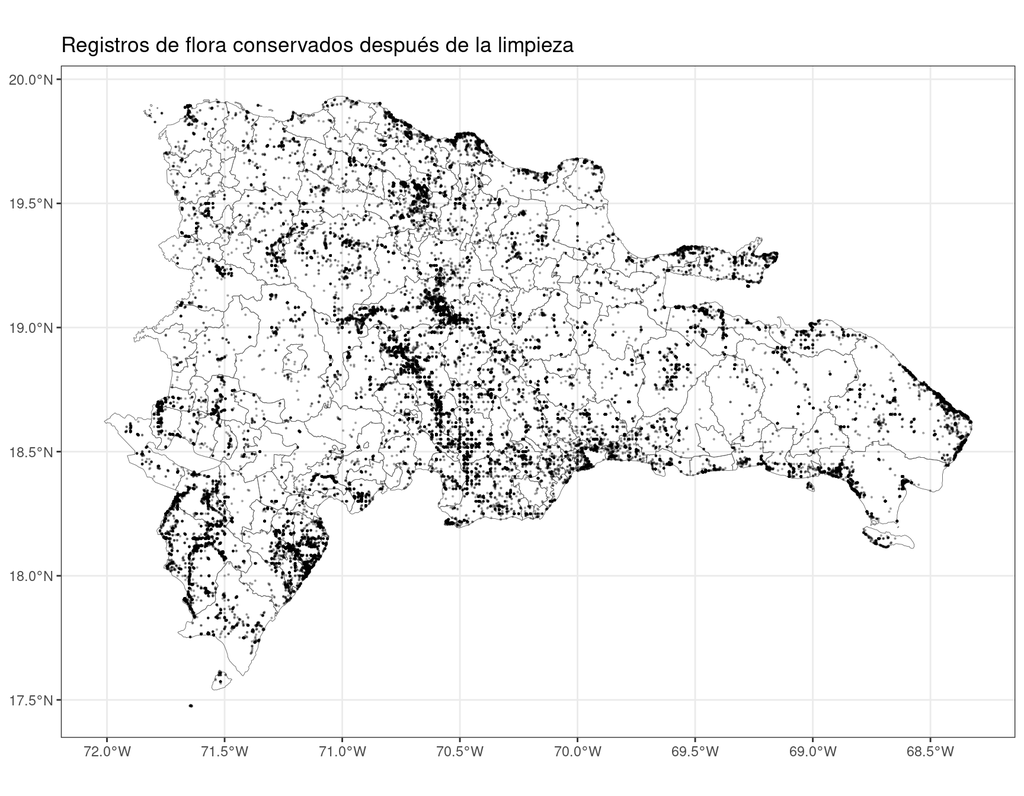

```r
ggplot() +
  geom_sf(data = municipios_ll, fill = NA, linewidth = 0.15) +
  geom_sf(data = pts_h3, size = 0.15, alpha = 0.25) +
  theme_bw() +
  labs(title = "Registros de flora conservados después de la limpieza")
```

# 15. Sesión